# **Used Cars Price Prediction**

### **3. Boxplot**

```python
# Custom function that will create boxplot w.r.t Price for any input categorical variable.
# This function takes the categorical column as the input and returns the boxplots for the variable.
def boxplot(z):
    plt.figure(figsize = (12, 5)) # Setting size of boxplot
    sns.boxplot(x = z, y = data['Price']) # Defining x and y
    plt.show()
    plt.figure(figsize = (12, 5))
    plt.title('Without Outliers')
    sns.boxplot(x = z, y = data['Price'], showfliers = False) # Turning off the outliers
    plt.show()
```

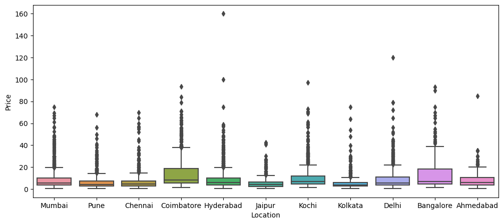

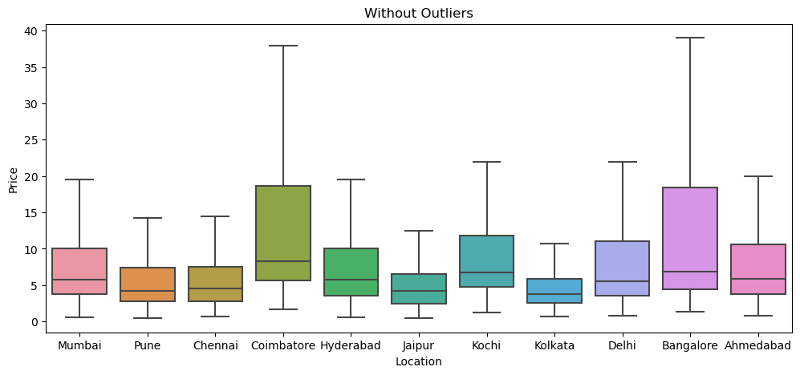

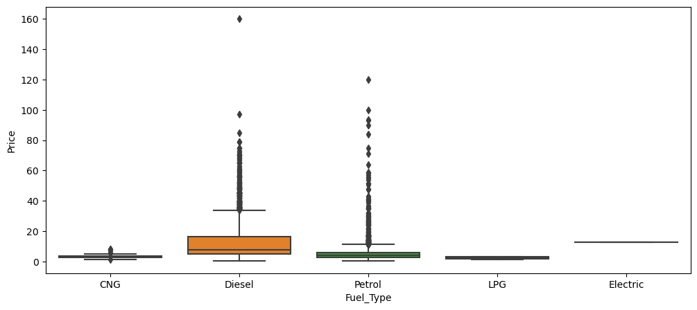

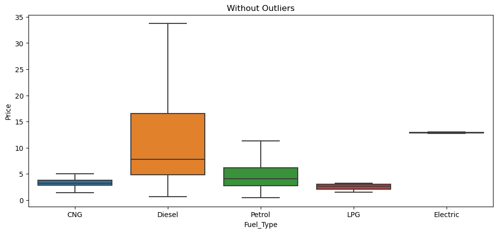

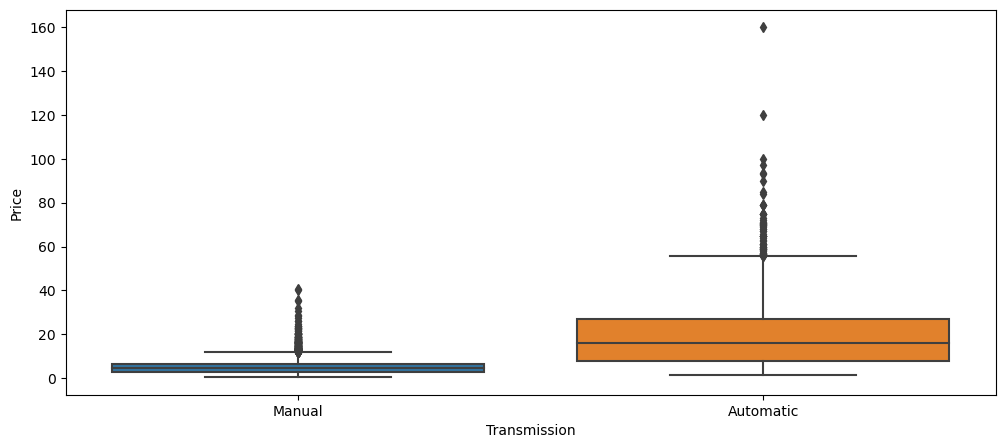

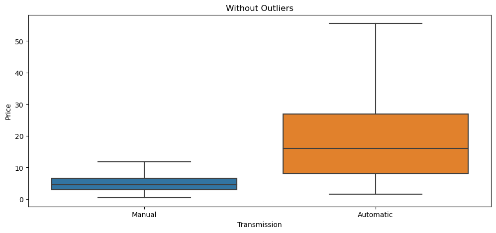

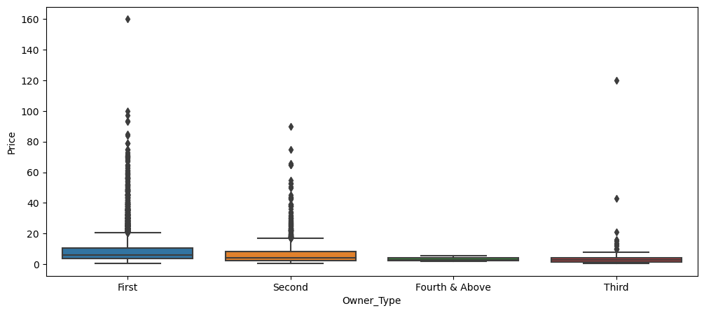

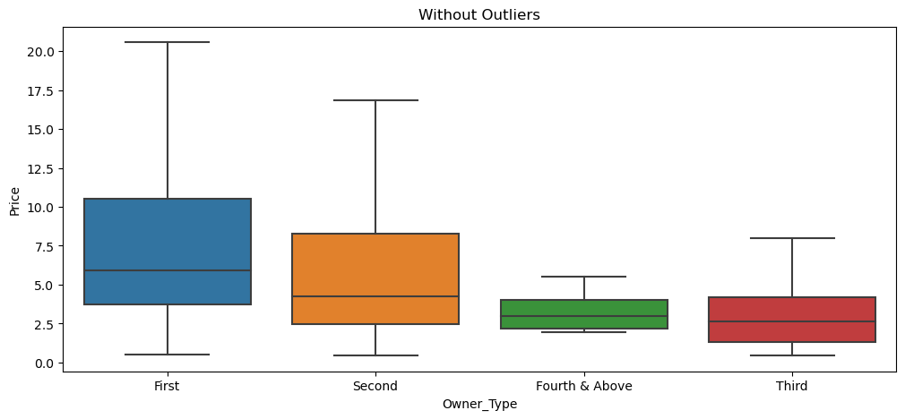

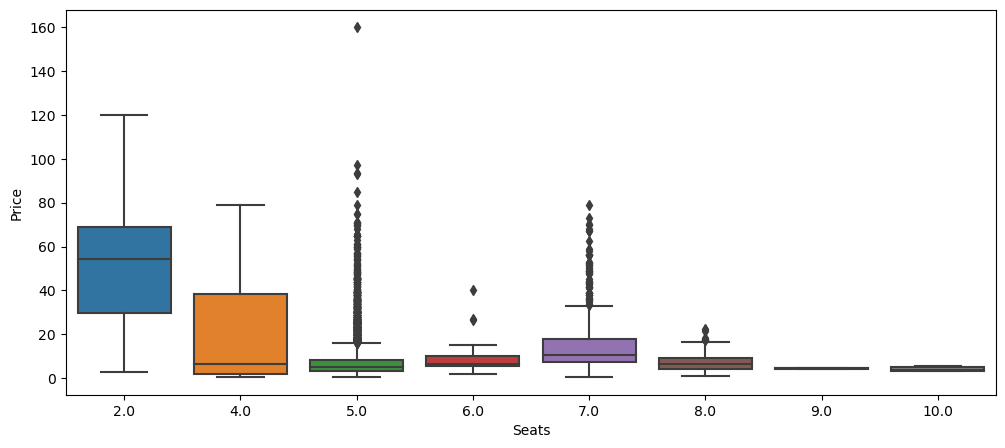

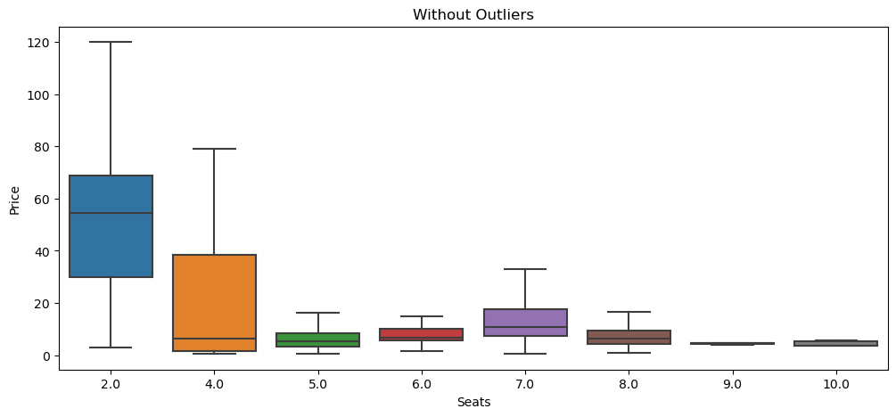

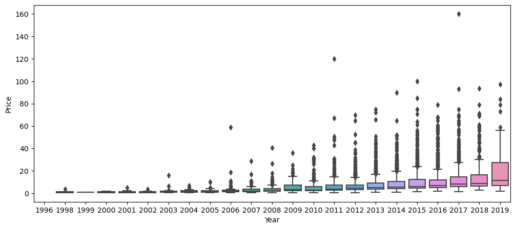

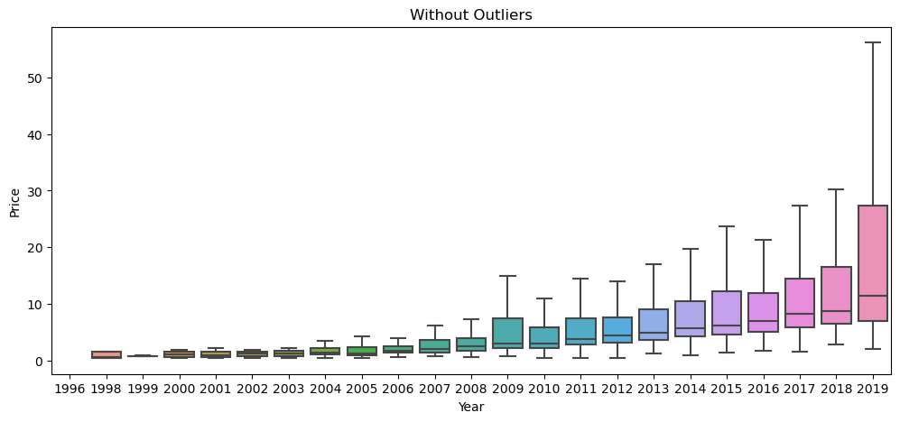

```python
for col in cat_col:
    if col != 'Name':
       boxplot(data[col])
```

Observation:

- Distribution of prices appears to be skewed in all location with significant outliers
- Electric fuel_types and automatic transmission types are generally more expensive on average
- Average price appears to decrease with more ownership

### **Feature Engineering**

**Extracting Brand name from 'Name' column**

- Some car brands are more appealing than others. Its reasonable to think that brand name might be a predictor used car prices
- I'll extract brand name from the 'Name' column

```python
data["Name"].nunique() #number of unique names of cars
```

```
2041
```

```python
#Extracting Brand Names
data["Brand"] = data["Name"].apply(lambda x: x.split(" ")[0].lower())
```

```python
data["Brand"].unique()
```

```
array(['maruti', 'hyundai', 'honda', 'audi', 'nissan', 'toyota',
       'volkswagen', 'tata', 'land', 'mitsubishi', 'renault',
       'mercedes-benz', 'bmw', 'mahindra', 'ford', 'porsche', 'datsun',
       'jaguar', 'volvo', 'chevrolet', 'skoda', 'mini', 'fiat', 'jeep',
       'smart', 'ambassador', 'isuzu', 'force', 'bentley', 'lamborghini',
       'hindustan', 'opelcorsa'], dtype=object)
```

**Extracting Age of cars from 'Year' column**

- Age of car would be a better predictor of price in linear regression model than year of manufacture.
- I'll extract 'Age' from the 'Year' column
- I'll drop 'Year' column

```python
#Age of car can be determined from the year of manufacture. This seems more appropriate for modelling than 'year of manufacture'
data['Age'] = 2023 - data['Year']
data = data.drop(['Year'], axis = 1)
```

### **Missing value treatment**

```python
data.isnull().sum() #checking number of missing values per column
```

```
Name                        0
Location                    0
Kilometers_Driven           0
Fuel_Type                   0
Transmission                0
Owner_Type                  0
Mileage                     2
Engine                     46
Power                     175
Seats                      53
New_price                6246
Price                    1234
kilometers_driven_log       0
Price_log                1234
Brand                       0
Age                         0
dtype: int64
```

**Missing values treatment for Mileage**

```python
data['Mileage'].isnull().sum()
```

```
2
```

```python
#Mileage has a near normal distribution. I'll be filling the missing values with the mean
data['Mileage'].fillna(data['Mileage'].mean(), inplace = True)
```

```python
data['Mileage'].isnull().sum()
```

```
0
```

```python
# Function to fill zero mileage with mean value
med = data['Mileage'].mean()
def fill_mean(x):
    if x == 0:
        return med
    else:
        return x

data['Mileage'] = data['Mileage'].apply(fill_mean)
```

**Missing values treatment for Engine size**

```python
#Engine size has a distorted distribution with many outliers. I'll be filling the missing values with the median
data['Engine'].fillna(data['Engine'].median(), inplace = True)
```

```python
data['Engine'].isnull().sum()
```

```
0
```

**Missing values treatment for Power**

```python
#Power has a distorted distribution with many outliers. I'll be filling the missing values with the median
data['Power'].fillna(data['Power'].median(), inplace = True)
```

```python
data['Power'].isnull().sum()
```

```
0
```

**Missing values treatment for Seats**

```python
#84% of observations have 5 seats which is also the median value. I'll be filling missing value with the median of 5 seats
data['Seats'].fillna(data['Seats'].median(), inplace = True)
```

```python
data['Seats'].isnull().sum()
```

```
0
```

```python
#data['Seats'].fillna(data[data.loc[:,'Name']==data['Name']]['Seats'].median(), inplace = True)
```

**Missing values treatment for New price**

```python
#New_price has a distorted distribution with many outliers. I'll be filling the missing values with the median
data['New_price'].fillna(data['New_price'].median(), inplace = True)
```

```python
data['New_price'].isnull().sum()
```

```
0
```

**Missing values treatment for price**

```python
data = data[data['Price'].notnull()] #filtering out/removing rows/observation without "Price"
```

Observations:

- All missing values have been treated
- 'New_price' has 86% of its rows missing. Filling the missing value will not provide significant prediction power. I'll check the regression result for this variable.
- Target variable (price) has 1234 missing values. Not helpful in building or assesing a model so i removed this rows

## **Important Insights from EDA and Data Preprocessing**

### **Splitting the Data**

Step1: Seperating the indepdent variables (X) and the dependent variable (y).

Step2: Encode the categorical variables in X using pd.dummies.

Step3: Split the data into train and test using train_test_split.

- I'll drop the following variables from target variable vector X:
  - 'Name': because it has 2041 unique entries and therefore has little to no predictive power
  - 'Price' and 'Price_log' because they are target variable vector Y
  - 'Kilometers_driven': because its now redundant since we have its log transformation

```python
y = data[["Price_log", "Price"]]
X = data.drop(['Name','Price','Price_log','Kilometers_Driven'], axis = 1) #'Kilometers_Driven'
```

```python
#Encoding the categorical variables in X using pd.dummies.
X = pd.get_dummies(X, drop_first = True)
```

```python
#Splitting the data into train and test using train_test_split.
X_train, X_test, y_train, y_test = train_test_split(X, y, test_size = 0.3, random_state = 1)
print(X_train.shape, X_test.shape)
```

```
(4212, 54) (1806, 54)
```

```python
#Keeping original versions of test and train datasets (before adding constant term) for lasso/ridge and tree-based models
X_train_original = X_train
X_test_original = X_test
y_train_original = y_train
y_test_original = y_test
```

```python
# Adding the intercept term for linear regression
X_train = sm.add_constant(X_train)
X_test = sm.add_constant(X_test)
```

### **Check for Multicollinearity**

```python
# Custome Function to check VIF
def checking_vif(train):
    vif = pd.DataFrame()
    vif["feature"] = train.columns
    # Calculating VIF for each feature
    vif["VIF"] = [
        variance_inflation_factor(train.values, i) for i in range(len(train.columns))
    ]
    return vif
print(checking_vif(X_train))
```

```
                      feature      VIF
0                       const 5014.801
1                     Mileage    3.886
2                      Engine   10.472
3                       Power    9.522
4                       Seats    2.492
5                   New_price    1.238
6       kilometers_driven_log    1.790
7                         Age    2.170
8          Location_Bangalore    2.366
9            Location_Chennai    2.817
10        Location_Coimbatore    3.447
11             Location_Delhi    3.025
12         Location_Hyderabad    3.701
13            Location_Jaipur    2.576
```

[output cut: 41 more lines]

Observation:

### Linear Regression Model

```python
olsmodel1 = sm.OLS(y_train["Price_log"], X_train).fit()
print(olsmodel1.summary()) #model summary
```

```
                            OLS Regression Results
==============================================================================
Dep. Variable:              Price_log   R-squared:                       0.922
Model:                            OLS   Adj. R-squared:                  0.921
Method:                 Least Squares   F-statistic:                     910.9
Date:                Thu, 15 Jun 2023   Prob (F-statistic):               0.00
Time:                        13:35:33   Log-Likelihood:                -20.688
No. Observations:                4212   AIC:                             151.4
Df Residuals:                    4157   BIC:                             500.4
Df Model:                          54
Covariance Type:            nonrobust
=============================================================================================
                                coef    std err          t      P>|t|      [0.025      0.975]
---------------------------------------------------------------------------------------------
const                         3.0553      0.267     11.440      0.000       2.532       3.579
Mileage                      -0.0169      0.002     -9.439      0.000      -0.020      -0.013
Engine                        0.0002   2.01e-05      8.512      0.000       0.000       0.000
Power                         0.0046      0.000     21.317      0.000       0.004       0.005
Seats                         0.0385      0.007      5.192      0.000       0.024       0.053
New_price                    -0.0003      0.000     -0.632      0.528      -0.001       0.001
kilometers_driven_log        -0.0641      0.007     -9.043      0.000      -0.078      -0.050
Age                          -0.1206      0.002    -71.338      0.000      -0.124      -0.117
Location_Bangalore            0.1711      0.025      6.916      0.000       0.123       0.220
Location_Chennai              0.0205      0.023      0.872      0.383      -0.026       0.067
Location_Coimbatore           0.1037      0.022      4.613      0.000       0.060       0.148
Location_Delhi               -0.0528      0.023     -2.311      0.021      -0.098      -0.008
Location_Hyderabad            0.1079      0.022      4.926      0.000       0.065       0.151
Location_Jaipur              -0.0684      0.024     -2.838      0.005      -0.116      -0.021
Location_Kochi               -0.0291      0.023     -1.289      0.197      -0.073       0.015
Location_Kolkata             -0.2378      0.023    -10.307      0.000      -0.283      -0.193
Location_Mumbai              -0.0347      0.022     -1.584      0.113      -0.078       0.008
Location_Pune                -0.0370      0.023     -1.638      0.101      -0.081       0.007
Fuel_Type_Diesel              0.2098      0.041      5.129      0.000       0.130       0.290
Fuel_Type_Electric            1.0485      0.249      4.208      0.000       0.560       1.537
Fuel_Type_LPG                -0.1131      0.102     -1.110      0.267      -0.313       0.087
Fuel_Type_Petrol             -0.0874      0.042     -2.075      0.038      -0.170      -0.005
Transmission_Manual          -0.1153      0.013     -9.180      0.000      -0.140      -0.091
Owner_Type_Fourth & Above     0.0106      0.110      0.096      0.923      -0.206       0.227
Owner_Type_Second            -0.0593      0.011     -5.348      0.000      -0.081      -0.038
Owner_Type_Third             -0.1254      0.029     -4.385      0.000      -0.181      -0.069
```

[output cut: 25 more lines]

```
Brand_tata                   -0.6538      0.248     -2.636      0.008      -1.140      -0.168
Brand_toyota                  0.0834      0.248      0.337      0.736      -0.402       0.569
Brand_volkswagen             -0.1447      0.248     -0.584      0.559      -0.630       0.341
Brand_volvo                   0.2946      0.255      1.154      0.249      -0.206       0.795
==============================================================================
Omnibus:                     1138.593   Durbin-Watson:                   2.012
Prob(Omnibus):                  0.000   Jarque-Bera (JB):            27262.404
Skew:                          -0.731   Prob(JB):                         0.00
Kurtosis:                      15.378   Cond. No.                     6.25e+05
==============================================================================

Notes:
[1] Standard Errors assume that the covariance matrix of the errors is correctly specified.
[2] The condition number is large, 6.25e+05. This might indicate that there are
strong multicollinearity or other numerical problems.
```

Observation:

- Some coefficients have p-values of greater than 5% (level of significance) which means we fail to reject the null hypothesis that those coefficients are zero. They are not statistically significant enough or have enough predictive power to predict the target variable.
- Decent R-squared and adjusted R-squared values of 0.92
- The true value of the coefficients of the remaining independent variables lie within the confidence interval with a 95% likelihood.
- Each 'coef' represents the change in the output Y due to a change of one unit in the variable (everything else held constant).
- 'std err' reflects the level of accuracy of the coefficients. The lower it is, the more accurate the coefficients are.

```python
#Storing Coefficients and p-values in a dataframe
olsmod = pd.DataFrame(olsmodel1.params, columns = ['coef'])
olsmod['pval'] = olsmodel1.pvalues
```

```python
# Filter by significant p-value (pval <= 0.05) and sort in descending order
olsmod = olsmod.sort_values(by = "pval", ascending = False)
pval_filter = olsmod['pval']<= 0.05
olsmod[pval_filter]
```

|  | coef | pval |
| --- | --- | --- |
| Brand_audi | 0.498 | 0.045 |
| Fuel_Type_Petrol | -0.087 | 0.038 |
| Brand_mercedes-benz | 0.521 | 0.036 |
| Location_Delhi | -0.053 | 0.021 |
| Brand_datsun | -0.607 | 0.020 |
| Brand_tata | -0.654 | 0.008 |
| Location_Jaipur | -0.068 | 0.005 |
| Brand_land | 0.811 | 0.001 |
| Brand_mini | 0.944 | 0.000 |
| Fuel_Type_Electric | 1.049 | 0.000 |
| Owner_Type_Third | -0.125 | 0.000 |
| Location_Coimbatore | 0.104 | 0.000 |
| Location_Hyderabad | 0.108 | 0.000 |
| Fuel_Type_Diesel | 0.210 | 0.000 |
| Seats | 0.039 | 0.000 |
| Owner_Type_Second | -0.059 | 0.000 |
| Location_Bangalore | 0.171 | 0.000 |
| Engine | 0.000 | 0.000 |
| kilometers_driven_log | -0.064 | 0.000 |
| Transmission_Manual | -0.115 | 0.000 |
| Mileage | -0.017 | 0.000 |
| Location_Kolkata | -0.238 | 0.000 |
| const | 3.055 | 0.000 |
| Power | 0.005 | 0.000 |
| Age | -0.121 | 0.000 |

```python
# getting overall significant varaible
pval_filter = olsmod['pval']<= 0.05
imp_vars = olsmod[pval_filter].index.tolist()


# getting overall variables (un-one-hot encoded varables) from categorical varaibles
sig_var = []
for col in imp_vars:
    if '' in col:
        first_part = col.split('_')[0]
        for c in data.columns:
            if first_part in c and c not in sig_var :
                sig_var.append(c)


start = '\033[1m'
end = '\033[95m'
print(start+ 'Most overall significant varaibles of LINEAR REGRESSION  are ' +end,':\n', sig_var)
```

```
Most overall significant varaibles of LINEAR REGRESSION  are  :
 ['Brand', 'Fuel_Type', 'Location', 'Owner_Type', 'Seats', 'Engine', 'kilometers_driven_log', 'Transmission', 'Mileage', 'Power', 'Age']
```

## Checking Linear Regression Assumptions

- In order to make statistical inferences from a linear regression model, it is important to ensure that the assumptions of linear regression are satisfied:
1. **Mean of residuals should be 0**
2. **No Heteroscedasticity**
3. **Linearity of variables**
4. **Normality of error terms**

#### **1. Check for mean residuals**

```python
residuals = olsmodel1.resid
np.mean(residuals)
```

```
8.755368488879167e-15
```

Observation:

- Practically zero mean of residuals. Assumption satisfied.

#### **2. Check for homoscedasticity**

- Homoscedasticity - If the residuals are symmetrically distributed across the regression line, then the data is said to be homoscedastic.
- Heteroscedasticity- - If the residuals are not symmetrically distributed across the regression line, then the data is said to be heteroscedastic. In this case, the residuals can form a funnel shape or any other non-symmetrical shape.
- I'll use `Goldfeldquandt Test` to test the following hypothesis with alpha = 0.05:
  - Null hypothesis: Residuals are homoscedastic
  - Alternate hypothesis: Residuals have heteroscedastic

```python
name = ["F statistic", "p-value"]
test = sms.het_goldfeldquandt(y_train_original["Price_log"], X_train_original)
lzip(name, test)
```

```
[('F statistic', 1.0791538068357729), ('p-value', 0.04219348468866001)]
```

**Observation:**

#### **3. Linearity of variables**

It states that the predictor variables must have a linear relation with the dependent variable. To test the assumption, I'll plot residuals and the fitted values on a plot and ensure that residuals do not form a strong pattern. They should be randomly and uniformly scattered on the x-axis.

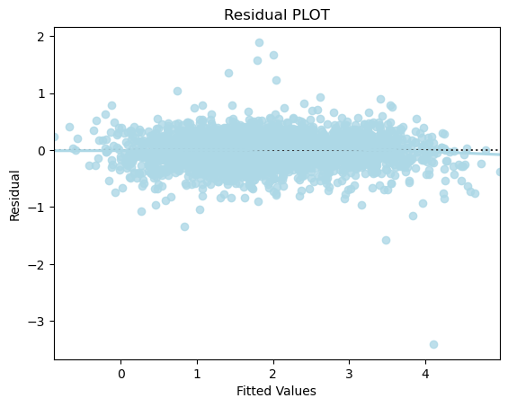

```python
# Predicted values
fitted = olsmodel1.fittedvalues
# sns.set_style("whitegrid")
sns.residplot(x = fitted, y = residuals, color = "lightblue", lowess = True)
plt.xlabel("Fitted Values")
plt.ylabel("Residual")
plt.title("Residual PLOT")
plt.show()
```

**Observation:**

- There is no pattern in the residual vs fitted values plot. Hence, the corresponding assumption is satisfied.

#### **4. Normality of error terms**

The residuals should be normally distributed.

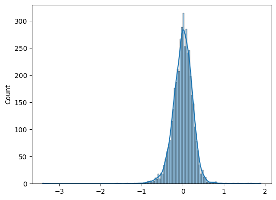

```python
# Plot histogram of residuals
sns.histplot(residuals, kde = True)
```

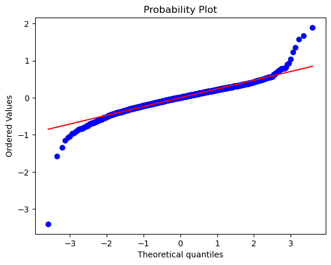

```python
stats.probplot(residuals, dist = "norm", plot = pylab)
plt.show()
```

**Observation:**

### Cross-Validation of Model

```python
# Build the regression model and cross-validate
linearregression = LinearRegression()
cv_Score11 = cross_val_score(linearregression, X_train_original, y_train_original["Price_log"], cv = 10)
cv_Score12 = cross_val_score(linearregression, X_train_original, y_train_original["Price_log"], cv = 10,
                             scoring = 'neg_mean_squared_error')
print("RSquared: %0.3f (+/- %0.3f)" % (cv_Score11.mean(), cv_Score11.std() * 2))
print("Mean Squared Error: %0.3f (+/- %0.3f)" % (-1*cv_Score12.mean(), cv_Score12.std() * 2))
```

```
RSquared: 0.918 (+/- 0.025)
Mean Squared Error: 0.062 (+/- 0.025)
```

**Observations:**

- The r2-score on cross-validation (0.92) is consistent with the r2-score of the model (0.92)
- My final model seems **a good fit**. It is giving a generalized performance.

### Model Performance Evaluation

The following metric will be used to assess model performances:

- r2-score: R-squared is a goodness-of-fit measure for regression models. It indicates the proportion of the variance in the dependent variable that is explained collectively by the independent/predictor variables.
- adjusted r2-score: ensures only meaningful/contributing predictors are considered.
- RMSE: The Root Mean Square of the Error/difference between actual and predicted target variable
- MAE: Mean Absolute Error indicates the average absolute difference between actual and predicted target variable. The units of both RMSE and MAE are the same (INR). But RMSE is greater than MAE because it penalizes the outliers more.

```python
# custom Functions for model performance evaluatiion

#Function to compute the adjusted R-square
def adj_r2_score(predictors, targets, predictions):
    r2 = r2_score(targets, predictions)
    n = predictors.shape[0]
    k = predictors.shape[1]
    return 1 - ((1 - r2) * (n - 1) / (n - k - 1))
# Function to compute MAPE
def mape_score(targets, predictions):
    return np.mean(np.abs(targets - predictions) / targets) * 100
# Function to compute different metrics to check performance of a regression model
def model_performance_regression(model, predictors, target):
    """
    Function to compute different metrics to check regression model performance
    model: regressor
    predictors: independent variables
    target: dependent variable
    """
    # Predicting using the independent variables
    pred = model.predict(predictors)
    r2 = r2_score(target, pred)                      # To compute R-squared
    adjr2 = adj_r2_score(predictors, target, pred)   # To compute adjusted R-squared
    rmse = np.sqrt(mean_squared_error(target, pred)) # To compute RMSE
    mae = mean_absolute_error(target, pred)          # To compute MAE
    #mape = mape_score(target, pred)                  # To compute MAPE

    # Creating a dataframe of metrics
    df_perf = pd.DataFrame(
        {
            "RMSE":  100000*np.exp(rmse),
            "MAE":  100000*np.exp(mae),
            "R-squared": r2,
            "Adj. R-squared": adjr2,
            #"MAPE": mape,
        },

        index = [0],
    )

    return df_perf
```

#### Model performance on training data

```python
lin_reg_perf = model_performance_regression(olsmodel1, X_train, y_train["Price_log"])
lin_reg_perf
```

|  | RMSE | MAE | R-squared | Adj. R-squared |
| --- | --- | --- | --- | --- |
| 0 | 127527.537 | 119647.638 | 0.922 | 0.921 |

#### Model performance on unseen test data

```python
lin_reg_perf = model_performance_regression(olsmodel1, X_test, y_test["Price_log"])
lin_reg_perf
```

|  | RMSE | MAE | R-squared | Adj. R-squared |
| --- | --- | --- | --- | --- |
| 0 | 126387.707 | 119762.714 | 0.929 | 0.927 |

**Observations:**

- Regression model giving idnetical performance on training and unseen test data. Model seems **a good fit**. It is giving a generalized performance.

#### Final Linear Regression Coefficients

```python
coef = olsmodel1.params
pd.DataFrame({'Feature' : coef.index, 'Coefs' : coef.values})
```

|  | Feature | Coefs |
| --- | --- | --- |
| 0 | const | 3.055 |
| 1 | Mileage | -0.017 |
| 2 | Engine | 0.000 |
| 3 | Power | 0.005 |
| 4 | Seats | 0.039 |
| 5 | New_price | -0.000 |
| 6 | kilometers_driven_log | -0.064 |
| 7 | Age | -0.121 |
| 8 | Location_Bangalore | 0.171 |
| 9 | Location_Chennai | 0.020 |
| 10 | Location_Coimbatore | 0.104 |
| 11 | Location_Delhi | -0.053 |
| 12 | Location_Hyderabad | 0.108 |
| 13 | Location_Jaipur | -0.068 |
| 14 | Location_Kochi | -0.029 |
| 15 | Location_Kolkata | -0.238 |
| 16 | Location_Mumbai | -0.035 |
| 17 | Location_Pune | -0.037 |
| 18 | Fuel_Type_Diesel | 0.210 |
| 19 | Fuel_Type_Electric | 1.049 |
| 20 | Fuel_Type_LPG | -0.113 |
| 21 | Fuel_Type_Petrol | -0.087 |
| 22 | Transmission_Manual | -0.115 |
| 23 | Owner_Type_Fourth & Above | 0.011 |
| 24 | Owner_Type_Second | -0.059 |
| 25 | Owner_Type_Third | -0.125 |
| 26 | Brand_audi | 0.498 |
| 27 | Brand_bentley | 0.183 |
| 28 | Brand_bmw | 0.473 |
| 29 | Brand_chevrolet | -0.434 |
| 30 | Brand_datsun | -0.607 |
| 31 | Brand_fiat | -0.408 |
| 32 | Brand_force | 0.025 |
| 33 | Brand_ford | -0.196 |
| 34 | Brand_honda | -0.057 |
| 35 | Brand_hyundai | -0.124 |
| 36 | Brand_isuzu | -0.353 |
| 37 | Brand_jaguar | 0.487 |
| 38 | Brand_jeep | 0.083 |
| 39 | Brand_lamborghini | 0.588 |
| 40 | Brand_land | 0.811 |
| 41 | Brand_mahindra | -0.268 |
| 42 | Brand_maruti | -0.128 |
| 43 | Brand_mercedes-benz | 0.521 |
| 44 | Brand_mini | 0.944 |
| 45 | Brand_mitsubishi | 0.151 |
| 46 | Brand_nissan | -0.162 |
| 47 | Brand_porsche | 0.265 |
| 48 | Brand_renault | -0.191 |
| 49 | Brand_skoda | -0.040 |
| 50 | Brand_smart | 0.144 |
| 51 | Brand_tata | -0.654 |
| 52 | Brand_toyota | 0.083 |
| 53 | Brand_volkswagen | -0.145 |
| 54 | Brand_volvo | 0.295 |

```python
#equation of the model
Equation = "Log(price)="
print(Equation, end='\t')
for i in range(len(coef)):
    print('(', round(coef[i],4), ') * ', coef.index[i], '+', end = ' ')
```

[output not shown]

#### Interpreting the Regression Coefficients

- Each 'coef' represents the change in the output Y due to a change of one unit in the variable (everything else held constant).
- The log of used car price increases with an increase in Location_Bangalore. 1 unit increase in the Location_Bangalore leads to an increase in log(price) ~ 0.17 times than the Location_Ahmedabad that serves as a reference variable when everything else is constant.
- The price prediction in INR(100,000) can be obtained by taking the exponent of log(price)

### Regularization Techniques

Regularization is a method of preventing a regression model from overfitting by adding additional information to it.

The machine learning model may perform well with training data but not with test data. It means that when dealing with unseen test data, the model cannot anticipate the result since it introduces noise into the output, and so the model is termed overfit. A regularization technique can be used to solve this problem.

By lowering the magnitude of the variables, this technique allows for the preservation of all variables or features in the model. As a result, it maintains accuracy as well as model generalization.

There are two main regularization techniques:

- Ridge regularization
- Lasso regularization

### Ridge Regression

```python
ridge_model = Ridge() #creating Ridge Regression model
ridge_model.fit(X_train_original, y_train_original["Price_log"])
```

```
Ridge()
```

#### Model performance on training data

```python
ridge_reg_perf = model_performance_regression(ridge_model, X_train_original, y_train_original["Price_log"])
ridge_reg_perf
```

|  | RMSE | MAE | R-squared | Adj. R-squared |
| --- | --- | --- | --- | --- |
| 0 | 127564.062 | 119650.552 | 0.922 | 0.921 |

#### Model performance on unseen test data

```python
ridge_reg_perf_test = model_performance_regression(ridge_model, X_test_original, y_test_original["Price_log"])
ridge_reg_perf_test
```

|  | RMSE | MAE | R-squared | Adj. R-squared |
| --- | --- | --- | --- | --- |
| 0 | 126454.400 | 119779.039 | 0.929 | 0.926 |

### Lasso Regression

```python
lasso_model = Lasso()
lasso_model.fit(X_train_original, y_train_original["Price_log"])
```

```
Lasso()
```

#### Model performance on training data

```python
lasso_reg_perf = model_performance_regression(lasso_model, X_train_original, y_train_original["Price_log"])
lasso_reg_perf
```

|  | RMSE | MAE | R-squared | Adj. R-squared |
| --- | --- | --- | --- | --- |
| 0 | 161772.374 | 143208.751 | 0.695 | 0.691 |

#### Model performance on unseen test data

```python
lasso_reg_perf_test = model_performance_regression(lasso_model, X_test_original, y_test_original["Price_log"]) #getting performance metrics on test data
lasso_reg_perf_test
```

|  | RMSE | MAE | R-squared | Adj. R-squared |
| --- | --- | --- | --- | --- |
| 0 | 158273.842 | 142749.713 | 0.727 | 0.719 |

Observation:

- Both ridge and lasso techniques gave generalized models performing similarly on training and unseen test data
- Ridge regularization appears to provide better performance on unseen test data

### XGBoost

```python
xgb = XGBRegressor()
xgb.fit(X_train_original, y_train_original["Price_log"])
```

```
XGBRegressor(base_score=None, booster=None, callbacks=None,
             colsample_bylevel=None, colsample_bynode=None,
             colsample_bytree=None, early_stopping_rounds=None,
             enable_categorical=False, eval_metric=None, feature_types=None,
             gamma=None, gpu_id=None, grow_policy=None, importance_type=None,
             interaction_constraints=None, learning_rate=None, max_bin=None,
             max_cat_threshold=None, max_cat_to_onehot=None,
             max_delta_step=None, max_depth=None, max_leaves=None,
             min_child_weight=None, missing=nan, monotone_constraints=None,
             n_estimators=100, n_jobs=None, num_parallel_tree=None,
             predictor=None, random_state=None, ...)
```

### K-Fold Cross-validation of XGBoost Regressor Model

```python
cv_Score11 = cross_val_score(xgb, X_train_original, y_train_original["Price_log"], cv = 10)
cv_Score12 = cross_val_score(xgb, X_train_original, y_train_original["Price_log"], cv = 10,
                             scoring = 'neg_mean_squared_error')
print("RSquared: %0.3f (+/- %0.3f)" % (cv_Score11.mean(), cv_Score11.std() * 2))
print("Mean Squared Error: %0.3f (+/- %0.3f)" % (-1*cv_Score12.mean(), cv_Score12.std() * 2))
```

```
RSquared: 0.943 (+/- 0.023)
Mean Squared Error: 0.044 (+/- 0.022)
```

#### Model performance on training data

```python
xgb_reg_perf = model_performance_regression(xgb, X_train_original, y_train_original["Price_log"])
xgb_reg_perf
```

|  | RMSE | MAE | R-squared | Adj. R-squared |
| --- | --- | --- | --- | --- |
| 0 | 109169.598 | 106745.799 | 0.990 | 0.990 |

#### Model performance on unseen test data

```python
xgb_reg_perf_test = model_performance_regression(xgb, X_test_original, y_test_original["Price_log"])
xgb_reg_perf_test
```

|  | RMSE | MAE | R-squared | Adj. R-squared |
| --- | --- | --- | --- | --- |
| 0 | 120140.312 | 113911.296 | 0.956 | 0.955 |

Observation:

- XGBoost regressor model appears to perform exceedingly well
- Consistent performance across, training, validation an test
- Great model, not overfit

### Decision Tree

```python
# Decision Tree Regressor
dt_regressor = DecisionTreeRegressor(random_state = 1)
# Fitting the model
dt_regressor.fit(X_train_original, y_train_original["Price_log"])
```

```
DecisionTreeRegressor(random_state=1)
```

#### Model performance on training data

```python
dt_regressor_perf_train = model_performance_regression(dt_regressor, X_train_original, y_train_original["Price_log"])
dt_regressor_perf_train
```

|  | RMSE | MAE | R-squared | Adj. R-squared |
| --- | --- | --- | --- | --- |
| 0 | 100271.610 | 100014.013 | 1.000 | 1.000 |

#### Model performance on unseen test data

```python
dt_regressor_perf_test = model_performance_regression(dt_regressor, X_test_original, y_test_original["Price_log"])
dt_regressor_perf_test
```

|  | RMSE | MAE | R-squared | Adj. R-squared |
| --- | --- | --- | --- | --- |
| 0 | 135726.171 | 122863.343 | 0.879 | 0.875 |

**Feature Importance From Decision Tree**

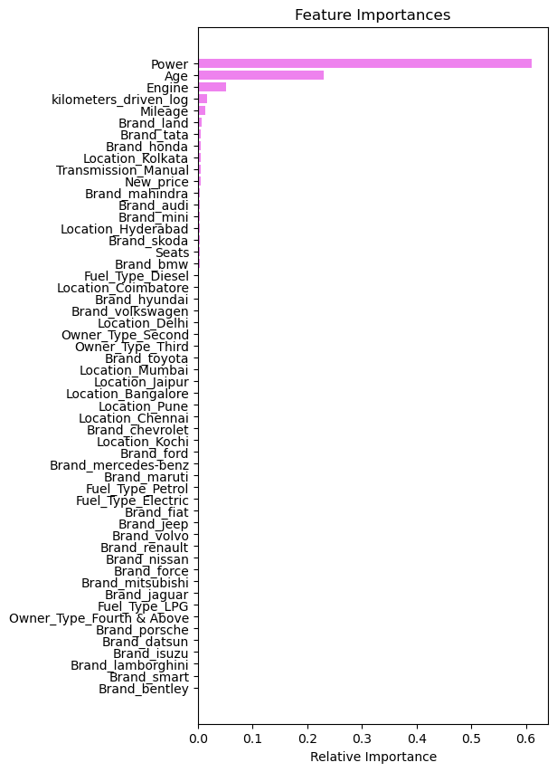

```python
# Plotting the feature importance
features = list(X_train_original.columns)
importances = dt_regressor.feature_importances_
indices = np.argsort(importances)
plt.figure(figsize = (5,10))
plt.title('Feature Importances')
plt.barh(range(len(indices)), importances[indices], color = 'violet', align = 'center')
plt.yticks(range(len(indices)), [features[i] for i in indices])
plt.xlabel('Relative Importance')
plt.show()
```

Observation:

- The decision tree model appears to be overfitted, performing better on training data than on unseen test data
- Most relevant features for pricing prediction are Engine Power, Age, Engine size, Mileage, kilometers_driven_log

### Random Forest

```python
# Random Forest Regressor
rf_regressor = RandomForestRegressor(random_state = 1)
# Fitting the model
rf_regressor.fit(X_train_original, y_train_original["Price_log"])
```

```
RandomForestRegressor(random_state=1)
```

#### Model performance on training data

```python
rf_regressor_perf = model_performance_regression(rf_regressor,X_train_original, y_train_original["Price_log"])
rf_regressor_perf
```

|  | RMSE | MAE | R-squared | Adj. R-squared |
| --- | --- | --- | --- | --- |
| 0 | 108881.426 | 105769.767 | 0.990 | 0.990 |

#### Model performance on unseen test data

```python
rf_regressor_perf_test = model_performance_regression(rf_regressor,X_test_original, y_test_original["Price_log"])
rf_regressor_perf_test
```

|  | RMSE | MAE | R-squared | Adj. R-squared |
| --- | --- | --- | --- | --- |
| 0 | 123408.968 | 115913.848 | 0.943 | 0.941 |

```python
#rf_regressor.predict(X_test_original)
```

**Feature Importance From Random Forest**

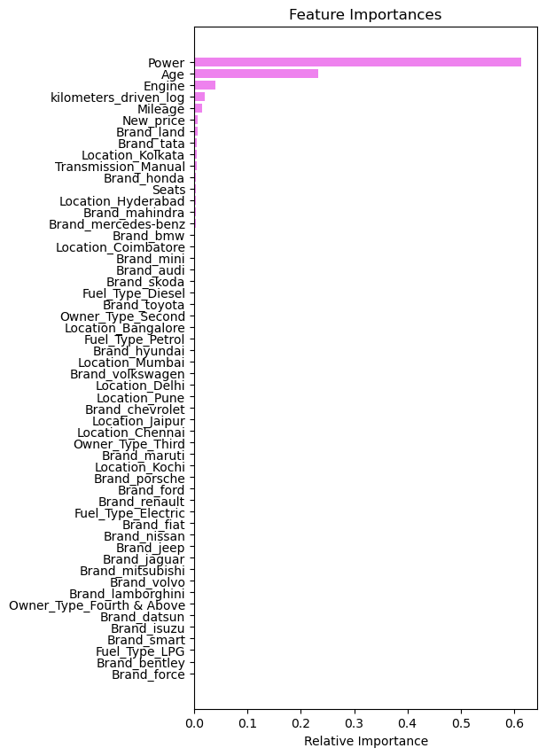

```python
# Plotting the feature importance
features = list(X_train_original.columns)
importances = rf_regressor.feature_importances_
indices = np.argsort(importances)
plt.figure(figsize = (5,10))
plt.title('Feature Importances')
plt.barh(range(len(indices)), importances[indices], color = 'violet', align = 'center')
plt.yticks(range(len(indices)), [features[i] for i in indices])
plt.xlabel('Relative Importance')
plt.show()
```

Observation:

- The random tree model appears to be a generalized model performing similarly on training and unseen test data
- Most relevant features for pricing prediction are Engine Power, Age, Engine size, kilometers_driven_log, Mileage. - - Similar relative feature importance as obtained with decision tree model

### **Hyperparameter Tuning: Lasso Regularization**

```python
model = Lasso(random_state = 1)#
parameters = {'alpha': [0.00001, 0.0001, 0.001, 0.01, 0.1, 1],
             }
# Run the grid search
grid_obj = GridSearchCV(model, parameters, scoring = 'r2', cv = 10)
grid_obj = grid_obj.fit(X_train_original, y_train_original["Price_log"])
```

```python
grid_obj.best_params_ #display best parameters
```

```
{'alpha': 1e-05}
```

```python
#Set the model to the best combination of parameters
lasso_tuned = grid_obj.best_estimator_
# Fit the best algorithm to the data
lasso_tuned.fit(X_train_original, y_train_original["Price_log"])
```

```
Lasso(alpha=1e-05, random_state=1)
```

#### Model performance on training data

```python
lasso_tuned_perf = model_performance_regression(lasso_tuned, X_train_original, y_train_original["Price_log"])
lasso_tuned_perf
```

|  | RMSE | MAE | R-squared | Adj. R-squared |
| --- | --- | --- | --- | --- |
| 0 | 127528.333 | 119646.848 | 0.922 | 0.921 |

#### Model performance on unseen test data

```python
lasso_tuned_perf_test = model_performance_regression(lasso_tuned, X_test_original, y_test_original["Price_log"])
lasso_tuned_perf_test
```

|  | RMSE | MAE | R-squared | Adj. R-squared |
| --- | --- | --- | --- | --- |
| 0 | 126391.779 | 119761.199 | 0.929 | 0.927 |

### **Hyperparameter Tuning: Decision Tree**

```python
model = DecisionTreeRegressor(random_state = 1)#, class_weight = {0: 0.3, 1: 0.7})
# Grid of parameters to choose from
parameters = {'max_depth': np.arange(2, 5, None),
              'min_samples_leaf': [2, 5, 10, 20, 25, 30]
             }
# Run the grid search
grid_obj = GridSearchCV(model, parameters, scoring = 'r2', cv = 10)
grid_obj = grid_obj.fit(X_train_original, y_train_original["Price_log"])
```

```python
grid_obj.best_params_ #display best parameters
```

```
{'max_depth': 4, 'min_samples_leaf': 10}
```

```python
#Set the model to the best combination of parameters
d_tree_tuned = grid_obj.best_estimator_
# Fit the best algorithm to the data
d_tree_tuned.fit(X_train_original, y_train_original["Price_log"])
```

```
DecisionTreeRegressor(max_depth=4, min_samples_leaf=10, random_state=1)
```

#### Model performance on training data

```python
# Model Performance on the training data, i.e., prediction
dt_regressor_tuned_perf = model_performance_regression(d_tree_tuned, X_train_original, y_train_original["Price_log"])
dt_regressor_tuned_perf
```

|  | RMSE | MAE | R-squared | Adj. R-squared |
| --- | --- | --- | --- | --- |
| 0 | 147206.739 | 133254.657 | 0.803 | 0.800 |

#### Model performance on unseen test data

```python
# Model Performance on the test data, i.e., prediction
dt_regressor_tuned_perf_test = model_performance_regression(d_tree_tuned, X_test_original, y_test_original["Price_log"])
dt_regressor_tuned_perf_test
```

|  | RMSE | MAE | R-squared | Adj. R-squared |
| --- | --- | --- | --- | --- |
| 0 | 147100.024 | 134344.378 | 0.807 | 0.801 |

**Feature Importance From Tuned Decision Tree**

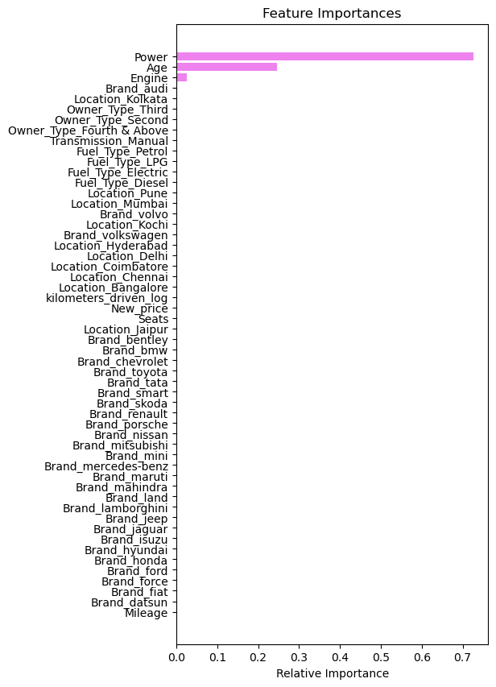

```python
# Plotting the feature importance
features = list(X_train_original.columns)
importances = d_tree_tuned.feature_importances_
indices = np.argsort(importances)
plt.figure(figsize = (5,10))
plt.title('Feature Importances')
plt.barh(range(len(indices)), importances[indices], color = 'violet', align = 'center')
plt.yticks(range(len(indices)), [features[i] for i in indices])
plt.xlabel('Relative Importance')
plt.show()
```

Observation:

### **Hyperparameter Tuning: Random Forest**

```python
# Choose the type of regressor
model = RandomForestRegressor(random_state = 1)#, class_weight = {0: 0.3, 1: 0.7})
# Grid of parameters to choose from
parameters = {'max_depth': np.arange(2, 5, None),
              'min_samples_leaf': [2,5, 10, 20, 25],
              "max_features": [0.6, 0.8, 1],
              "n_estimators": [100, 150, 200],
             }
# Run the grid search
grid_obj = GridSearchCV(model, parameters, scoring = 'r2', cv = 10)
grid_obj = grid_obj.fit(X_train_original, y_train_original["Price_log"])
```

```python
grid_obj.best_params_ #display best parameters
```

```
{'max_depth': 4,
 'max_features': 0.6,
 'min_samples_leaf': 2,
 'n_estimators': 150}
```

```python
#Set the regressor to the best combination of parameters
rf_tuned = grid_obj.best_estimator_
# Fit the best algorithm to the data
rf_tuned.fit(X_train_original, y_train_original["Price_log"])
```

```
RandomForestRegressor(max_depth=4, max_features=0.6, min_samples_leaf=2,
                      n_estimators=150, random_state=1)
```

#### Model performance on training data

```python
rf_regressor_tuned_perf = model_performance_regression(rf_tuned, X_train_original, y_train_original["Price_log"])
rf_regressor_tuned_perf
```

|  | RMSE | MAE | R-squared | Adj. R-squared |
| --- | --- | --- | --- | --- |
| 0 | 139999.246 | 128134.199 | 0.851 | 0.849 |

#### Model performance on unseen test data

```python
rf_regressor_tuned_perf_test = model_performance_regression(rf_tuned, X_test_original, y_test_original["Price_log"])
rf_regressor_tuned_perf_test
```

|  | RMSE | MAE | R-squared | Adj. R-squared |
| --- | --- | --- | --- | --- |
| 0 | 139081.870 | 128960.097 | 0.859 | 0.855 |

**Feature Importance from Tuned Random Forest**

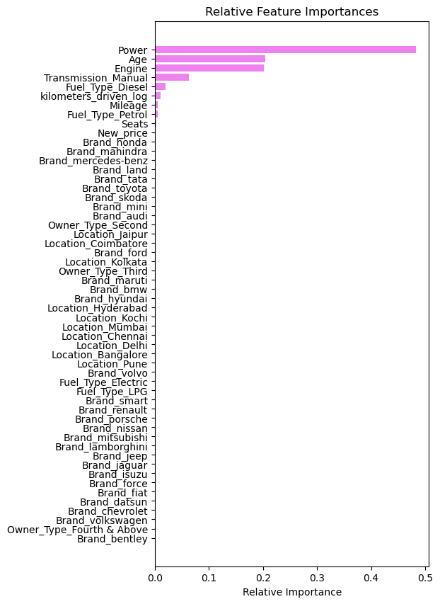

```python
# Plotting the feature importance
features = list(X_train_original.columns)#[0:10,:]
importances = rf_tuned.feature_importances_
indices = np.argsort(importances)
plt.figure(figsize = (5,10))
plt.title('Relative Feature Importances')
plt.barh(range(len(indices)), importances[indices], color = 'violet', align = 'center')
plt.yticks(range(len(indices)), [features[i] for i in indices])
plt.xlabel('Relative Importance')
plt.show()
```

Observation:

- The tuned random forest model appears to be giving a generalized model performing similarly on training and unseen test data.
- Performance on unseen test data appear to be lower than that of untuned random forest model.
- Most relevant features for pricing prediction are Engine Power, Age, Engine size, Transmission type, fuel_type kilometers_driven_log, Mileage according to this model.

## **Conclusions and Recommendations**

**1. Comparison of various techniques and their relative performance based on chosen Metrics (Measure of success):**

```python
#code to combine all model performance on unseen test data
models_test_comp_df = pd.concat(
    [
        lin_reg_perf.T,
        ridge_reg_perf_test.T,
        lasso_reg_perf_test.T,
        lasso_tuned_perf_test.T,
        dt_regressor_perf_test.T,
        dt_regressor_tuned_perf_test.T,
        rf_regressor_perf_test.T,
        rf_regressor_tuned_perf_test.T,
        xgb_reg_perf_test.T
    ],
    axis = 1,
)

models_test_comp_df.columns = [
    "Linear Regressor(OLS)",
    "Ridge Regressor (Default)",
    "Lasso Regressor (Default)",
    "Lasso Regressor (Tuned)",
    "Decision Tree Regressor (Default)",
    "Decision Tree Regressor (Tuned)",
    "Random Forest Regressor (Default)",
    "Random Forest Regressor (Tuned)",
    "XGBoost Regressor (Default)"
   ]

print("Test performance comparison:")
models_test_comp_df.T.style.highlight_max(color = "lightgreen", axis = 0).highlight_min(color = "lightblue", axis = 0)
```

```
Test performance comparison:
```

|  | RMSE | MAE | R-squared | Adj. R-squared |
| --- | --- | --- | --- | --- |
| Linear Regressor(OLS) | 126387.706546 | 119762.714162 | 0.928993 | 0.926761 |
| Ridge Regressor (Default) | 126454.400493 | 119779.039182 | 0.928673 | 0.926473 |
| Lasso Regressor (Default) | 158273.841566 | 142749.712672 | 0.727034 | 0.718616 |
| Lasso Regressor (Tuned) | 126391.779174 | 119761.198952 | 0.928973 | 0.926783 |
| Decision Tree Regressor (Default) | 135726.171149 | 122863.343147 | 0.879185 | 0.875459 |
| Decision Tree Regressor (Tuned) | 147100.024235 | 134344.377786 | 0.807144 | 0.801197 |
| Random Forest Regressor (Default) | 123408.968062 | 115913.847907 | 0.942720 | 0.940953 |
| Random Forest Regressor (Tuned) | 139081.869903 | 128960.096735 | 0.859093 | 0.854748 |
| XGBoost Regressor (Default) | 120140.312338 | 113911.296265 | 0.956407 | 0.955063 |

- R-squared is a goodness-of-fit measure for linear regression models. The untuned XGBoost regressor model has the best fit (0.96). This indicates that 96% of the variance in the dependent variable can be explain collectively by the independent variables. The performance of the XGBoost regression model on unseen test data means its able to correctly predict 96% of the target variable (log(price)) with mean absolute error of ~114,000INR and root mean square error of ~120,000INR.
- The random forest model also performs the well in terms of having the next best RMSE and MAE.
- Linear regression and ridge models are the next best models and appear to have identical performance on unseen test data with 93% goodness-of-fit measure, ~126,000INR RMSE and ~120,000 MAE.
- Ridge regularization appears to provide better performance on unseen test data than Lasso.
- Lasso model performance significantly improved by doing extensive hyper-parameter tuning. The GridSearchCV tuned alpha = ~0 which makes it essentially a linear model.
- Although hyper-parameter tuning did not improve the performance of the decision tree and random forest models. Maybe a more thorough gridsearch could achieve this.
- For all models, the price prediction in INR (100,000) can be obtained by taking the exponent of target variable (log(price)) calculated by the models.

**2. Refined insights:**

**3. Proposal for the final solution design:**